# Prepocessing lung cancer data included pooled samples

Kajsa Mollersen

02/03/2017

We’re doing here several preprocessings. The preprocessing has two different things going on: (1) Transform the expression from the raw value to something that is i.i.d. (2) Reduce the number of probes. Note that (1) and (2) are independent of each other, so the execution order doesn’t matter.

1. I will do this in two manners:  
   (Normexp) According to the original code from Hege Bvelstad: Hege_preprocessing.Rmd, title: “lung-cancer-data-preprocessing”, author: “Hege MB”, date: “4 Feb 2016”.  
   (Kajsa) which I haven’t decided on yet, but this is in case I desagree with Hege. There is an interesting paper, ‘Optimizing the noise versus bias trade-off…’, Shi et al (2010), that analyses pre-processing methods. One method they use is the same as Hege is using. Their conclusion is that there is no best pre-processing method, and they are all the same if you add the right offset. But there is no suggestion on how to find the right offset.
2. We will create datasets of four different sizes. (i) Full sized: no probes removed. (ii) Illumina size: only Bad probes and No match (according to IlluminaHumanv4) are removed. (iii) DetectionP: Those probes with a “detection p-value” < 0.01, and presens < 0.01 are removed (in addition to Bad and No match). (iv) Variance: Those probes with variance < noise variance are removed (in addition to Bad and No match). I haven’t figured out just yet how to do (iv).

The data set includes the 12 pooled samples. We keep them for quality control.

This data is created by the ‘create_lumi_object.R’ file, and contains the 12 pooled samples. I have run nowaclean on them, but no obvious outliers were detected, hence none removed.

```r
datapath <- "/Volumes/kam025/Documents/LungCancer/Discrete_curve_group_NR_method/Preprocessing/ReadData/"
load(paste(datapath,"LungCancerPooled.RData", sep = ""))
ls()
```

```
[1] "datapath"         "lobj"             "negativeCtrls"    "overview.data"
[5] "samplesheet.data"
```

```r
ctrlData <- controlData(lobj)
negCtrl <- ctrlData[ctrlData[,1]=="NEGATIVE",]
negCtrl <- negCtrl[,-(1:2)]
dim(negCtrl)
```

```
[1] 770 272
```

This transformation includes background correction using negative controls, normexp transformation, and quantile normalisation (not using positive controls, why?).

```r
totalData <- rbind(exprs(lobj),negCtrl) # use the neg controls for background correction
status <- c(rep("regular",nrow(exprs(lobj))), rep("negative", nrow(negCtrl))) # assign status
totalData.nec <- nec(totalData, status)
exprs.nec <- totalData.nec[which(status=="regular"),] # exclude the negative controls
nec.obj <- lobj
# make a lumi object where only the expression values have changed
exprs(nec.obj) <- exprs.nec
# quantile normalisation of the backgr.corr. + normexp exprs values
norm.obj <- lumiN(nec.obj,method= "quantile")
```

```
Perform quantile normalization ...
```

We plot the three versions of the expression values. I am not sure what I am looking for

```r
par(mfrow = c(1,3))
Qlobj <- lumiQ(lobj)
```

```
Perform Quality Control assessment of the LumiBatch object ...
```

```r
plot(Qlobj ,what = "density", legend = FALSE, col = 1, lwd = .05, xlim = c(4,12),
     main = "Raw data")
Qnobj <- lumiQ(nec.obj)
```

```
Perform Quality Control assessment of the LumiBatch object ...
```

```r
plot(Qnobj ,what = "density", legend = FALSE, col = 1, lwd = .05, xlim = c(4,12),
     main = "Backgr. corr. + normexp")
normQ <- lumiQ(norm.obj)
```

```
Perform Quality Control assessment of the LumiBatch object ...
```

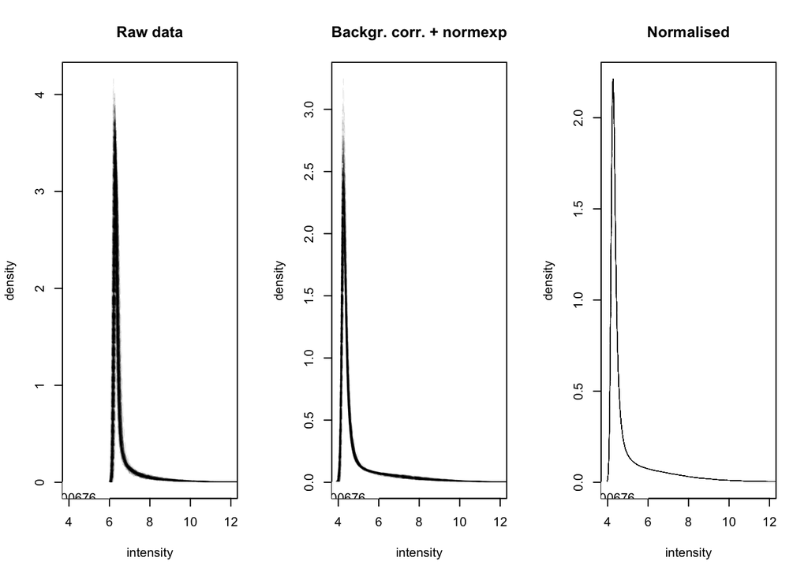

```r
plot(normQ ,what = "density", legend = FALSE, col = 1, lwd = .05, xlim = c(4,12),
     main = "Normalised")
```

Saving Normexp(i)

```r
save(norm.obj, file="Normexp_Full.RData")
```

This is Normexp(ii). We are now removing ‘Bad probes’ and ‘No match’ as defined by illuminaHumanv4.

```r
probes <- nuID2IlluminaID(as.character(featureNames(lobj)), lib.mapping=NULL,
                          species = "Human",idType = 'Probe')
probe.quality <- unlist(mget(as.character(probes), illuminaHumanv4PROBEQUALITY,
                             ifnotfound = NA))
which(is.na(probe.quality)) # just checking for NA's
```

```
named integer(0)
```

```r
length(which(probe.quality=="Bad")) # Lots of Bad quality probes
```

```
[1] 12379
```

```r
length(which(probe.quality=="No match")) # Just a few without a match
```

```
[1] 468
```

```r
ok.quality <- !((probe.quality == "Bad")|(probe.quality == "No match"))
# Extracting the ok quality probes from the pre-processed lumi object
ok.obj <- norm.obj[ok.quality,]
dim(ok.obj) # Checking the dimension
```

```
Features  Samples
   34476      272
```

Saving Normexp(ii):

```r
save(ok.obj, file="Normexp_Illumina.RData")
```

Remove those probes with detection p-value < 0.01 for less than 1% of the individuals. “The intensity associated with a certain detection p value corresponds to the respective upper quantile (percentile) of the (probability) distribution of the intensities of the negative controls.” This quote is from the internet. I have written an e-mail to Illumina tech support to get the exact definition.

```r
detection.pval <- 0.01  # Set the limits
present.limit <- 0.01
presentLim <- present.limit*ncol(ok.obj)
# At least this many ladies must have detection p-value above the limit for a probe to be
# "present".
presentLim
```

```
Samples
   2.72
```

```r
present_count <- detectionCall(ok.obj, Th=detection.pval, type ='probe')
present <- (present_count > presentLim)
present.obj <- norm.obj[present,]
dim(present.obj)
```

```
Features  Samples
   24737      272
```

Saving Normexp(iii):

```r
save(ok.obj, file="Normexp_Present.RData")
```